# Viticulture in Germany

After Work Insights into Data

Published

May 15, 2023

Modified

May 21, 2024

## 1 German Wine Regions

Germany is renowned for its wine regions, which produce a wide variety of high-quality wines. The country’s wine culture has a rich history dating back centuries and is characterized by its unique terroirs and grape varieties. Among the most famous wine regions are the Mosel Valley, known for its steep vineyards and outstanding Riesling wines, and the Rheingau, famous for its elegant and aromatic white wines. The Pfalz region boasts a mild climate and offers a wide range of white and red wines. Franconia stands out for its distinctive Bocksbeutel bottles and its focus on the Silvaner grape. The Baden region in the southern part of the country is Germany’s warmest wine-growing area, producing a variety of wines, from Pinot Noir to Pinot Gris.

The most important federal state is Rhineland-Palatinate with approximately 64,740 hectares followed by Baden-Württemberg with around 27,100 hectares. Germany has 13 official wine regions (each being protected designation of origin), each with its unique characteristics and wine styles. These regions collectively cultivate about 100,000 hectares [^1] of vineyards, making Germany one of the northernmost wine-producing countries in the world.

Vineyards are usually located in especially sheltered areas near rivers and have slopes that are steep, facing south or west to optimize sun exposure. The soils inclined toward the sun store heat energy throughout the day, which they continue to release long after sunset, preventing early-night frosts. The steep valley slopes also ensure a rapid flow of cold air. The northern position of German wine regions necessitates significant efforts in cultivating early-ripening and winter-hardy grape varieties.

The annual german total wine production fluctuates but typically ranges from 9 to 10 million hectoliters.

But let’s take a closer look at viticulture in Germany and see what we can learn from the data.

**Category: Red Wine**

When refered to ‘red wine’ category in this data analysis, it also encompasses rosé wine and ‘Rotling’ varieties.

Figure Figure 1 shows a map of Germany highlighting the 13 protected wine-growing regions. The largest is Rheinhessen with 26,685 ha, the smallest is the Hessische Bergstraße with 431 ha.

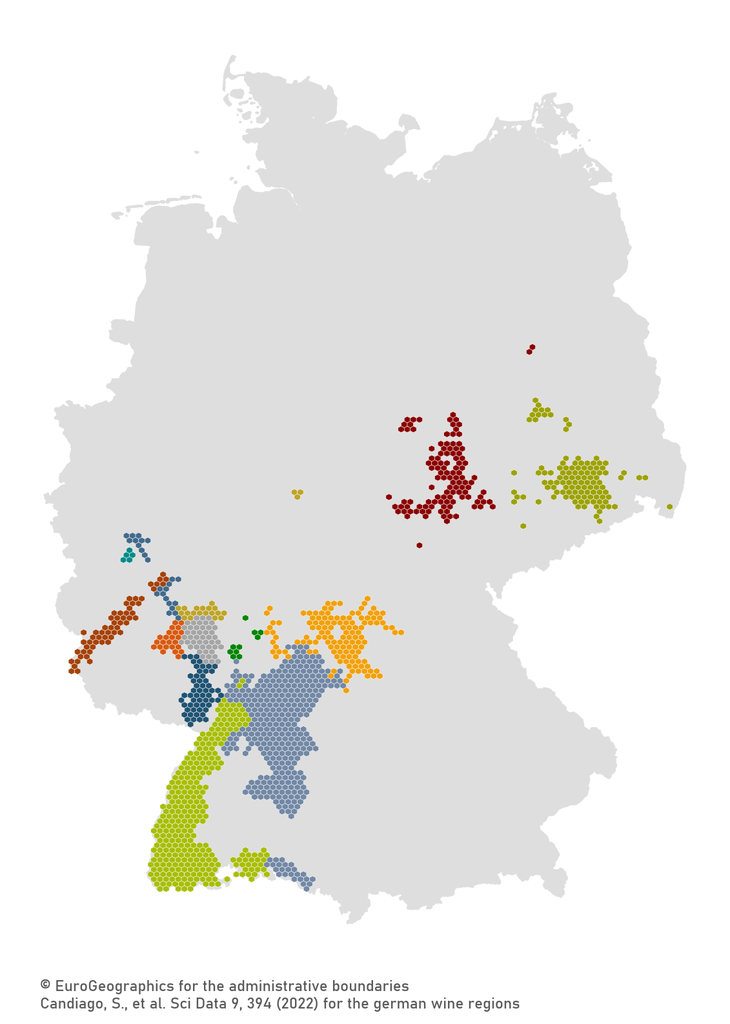

Figure 1: The 13 wine-growing regions in Germany. [^2] Vineyards are usually located in especially sheltered areas near rivers and feature slopes facing south or west to optimize sun exposure.

## 2 Viticulture in Bavaria

Let’s take a look at winegrowing in Bavaria, before we look at winegrowing in Germany as a whole again. Viticulture in Bavaria, a region better known for its beer, boasts a rich and unique tradition of wine production, particularly in the Franconia area. This picturesque region, with its rolling hills and river valleys, provides an ideal microclimate for cultivating a variety of grapes, most notably the Silvaner, which thrives in the mineral-rich soils. Bavarian winemakers combine centuries-old techniques with modern innovations to produce wines that are celebrated for their distinct character and quality. The region’s vineyards are often characterized by their terraced slopes, which maximize sun exposure and enhance the grapes’ flavors. The wines from Bavaria, particularly the crisp and aromatic white wines, are gaining increasing recognition both nationally and internationally, solidifying the area’s reputation as a notable wine-producing region in Germany.

The following figures visualize the areas under vines graphically. Figure 2 presents the absolute areas categorized into red wines and white wines. A weak but continous growth in vineyards area from 5,962 ha to 6,274 ha can be observed in the years 1991 to 2022. A phase of large increases in area can be clearly seen from the mid-1990s onwards. The area under red grapes grew from around 280 ha to over 1,200 ha. From 2009 onwards, the proportion fell again slightly to just over 1100 ha.

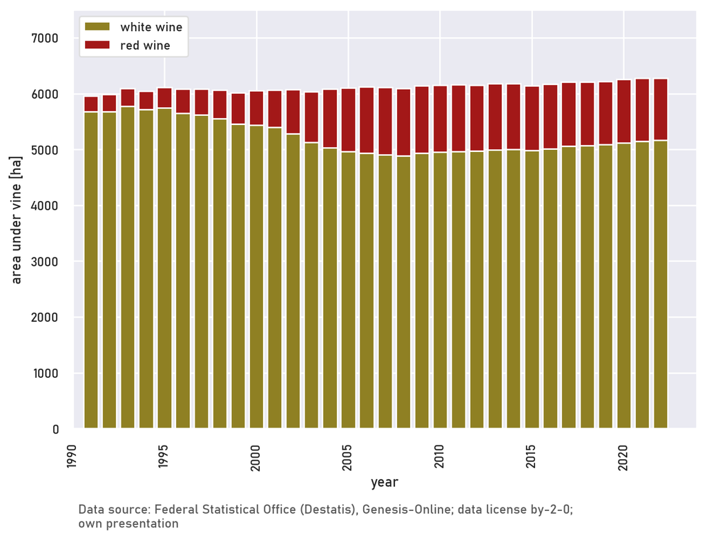

Figure 2: Absolute areas under vines in Bavaria for the years 1991 - 2022 categroized by red and white grapes. A weak but continous growth in vineyards area from 5,962 ha to 6,274 ha can be observed.

The growing share of red grapes on the total area becomes clearer when the respective areas are viewed in relative terms (see Fig. Figure 3). The largest share of red grapes can be seen in 2008, when they accounted for just under 20% of the total area. The area decreased again until 2022, consolidating the dominance of white grapes in Frankonia with a share of just over 82%.

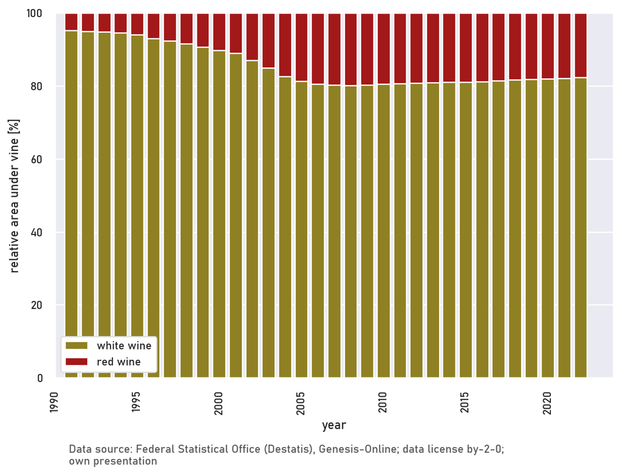

Figure 3: White and red grapes share on the total area in Bavaria for the years 1991 - 2022. The largest share of red grapes can be seen in 2008, when they accounted for just under 20% of the total area. White grapes dominate with a share of more than 82% of the total area.

## 3 Red and White Wine: A Detailed Look at Germany

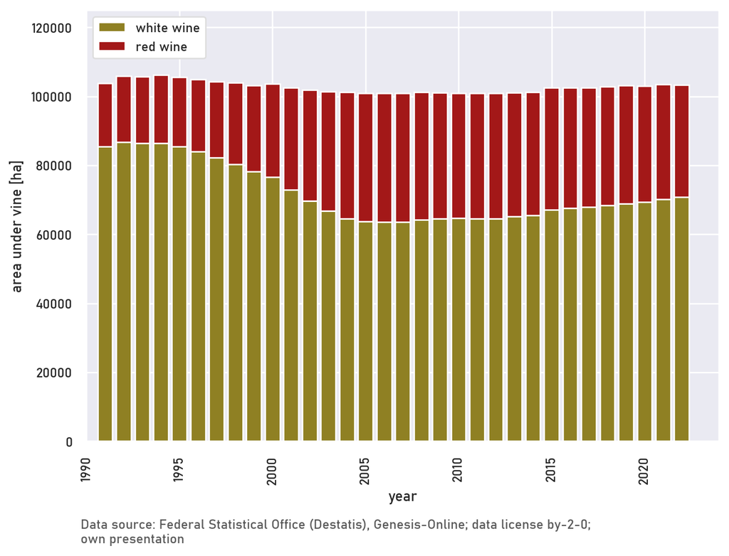

If the relative shares are considered (compare Figure 5), it is also noticeable for Germany as a whole that a boom in red grapes began in the mid-1990s and lasted until around 2007. In this year, red grapes reached their largest share with just under 37% of the total area under cultivation.

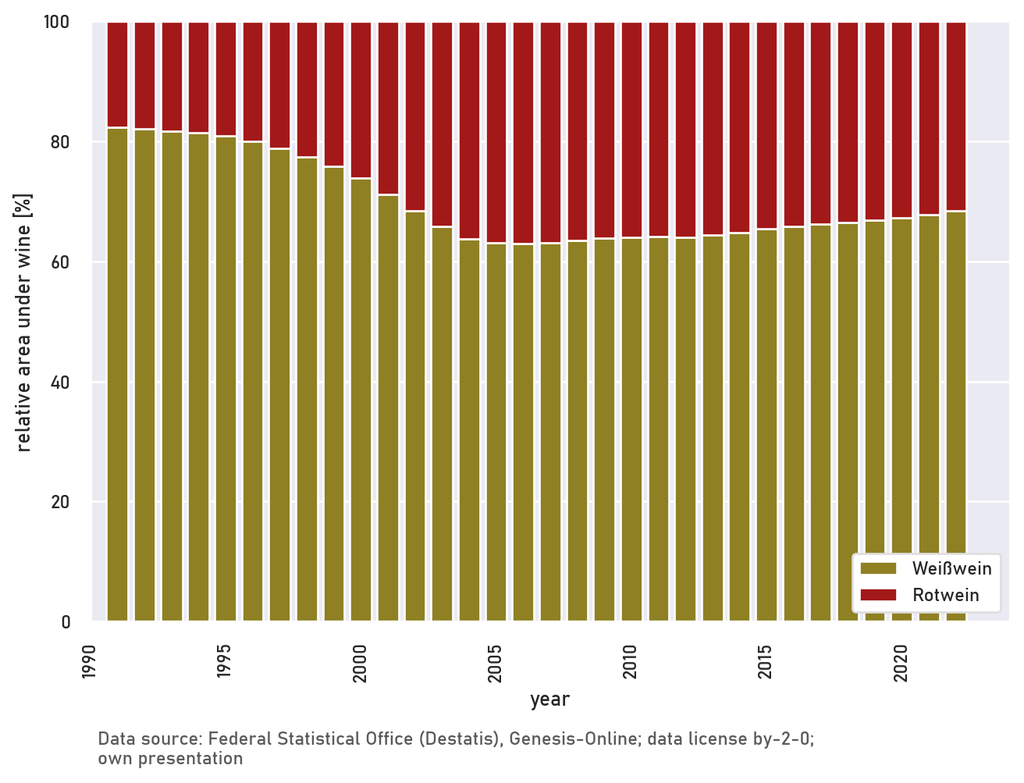

Figure 5: White and red grapes share on the total area in Germany for the years 1991 - 2022 categroized by red and white grapes. The largest share of red grapes can be seen in 2007, when they accounted for roughly 37% of the total area. In the year 2022 white grapes dominated with a share of more than 68% of the total area.

**Category: Area Details**

Yields per hectare are based on the area under vines, which is lower than the total planted area due to newly planted vineyards.

The largest wine-growing regions in Germany also have the highest wine must yields per hectare, as can be seen in Figure 6. The Palatinate (or *Pfalz*, as in the Figure) wine-growing region has the highest wine must yield at over 100 hectolitres per hectare, directly followed by Rheinhessen with just under 100 hectolitres per hectare, underlining their outstanding importance for viticulture in Germany. The smaller wine-growing regions tend to have lower must yields (Saxony is the smallest wine-growing region in this analysis and has the lowest yield with less than 50 hectolitres per hectare), but this in no way indicates poorer quality.

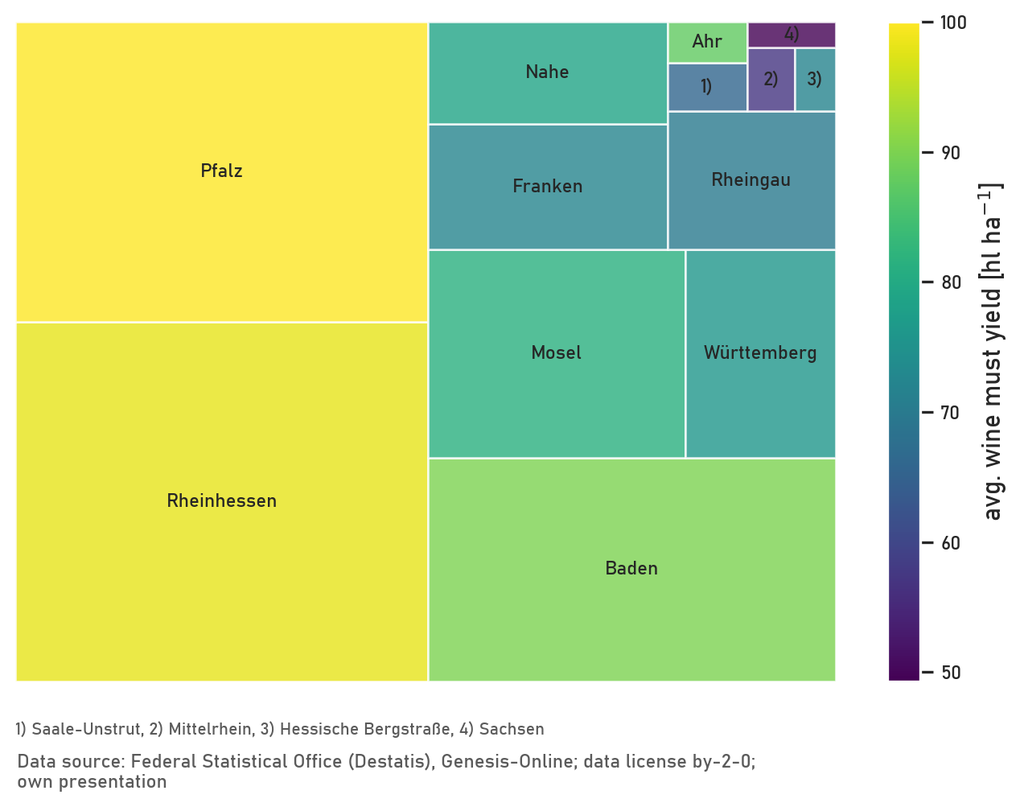

Figure 6: Representation of area shares of the wine-growing regions and the respective wine must yields. The size of the rectangles is proportional to the area under vines. The biggest wine-growing regions Pfalz and Rheinhessen have the highest yields, each with around 100 hl per hectare.

Looking at a map of Germany (see Figure 7), one can clearly see that the wine-growing areas of Germany in the southwest produce the highest yields, which can be explained by the more favorable climatic conditions in the respective regions.

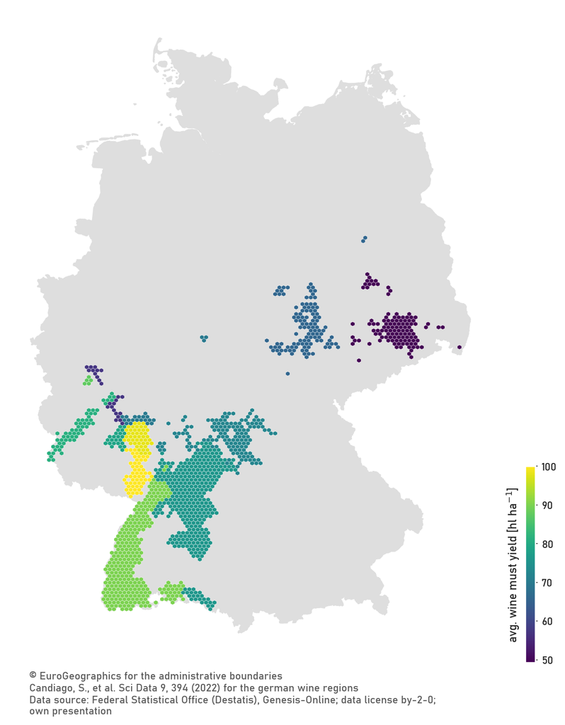

Figure 7: The 13 wine-growing regions in Germany [^3] colored according to the respective wine must yields. regions in the southwest produce the highest yields.

Let us conclude by taking a look at the grape varieties for selected wine-growing regions in Figure 8. In Franconia (*Franken*, respectively), white grapes clearly dominate, especially Müller-Thurgau and Grüner Silvaner both making up for more than 72% of the area under vines in Franconia, with Müller-Thurgau having the highest must yield in Franconia with an average of 81.6 hl per hectare. In the Palatinate (*Pfalz*, respectively), vines of the variety “Weißer Riesling” cover the largest area with 5,821 ha. However, vines of the Dornfelder and Müller-Thurgau varieties produce the highest must yields with 122 and 124 hl per hectare, respectively.

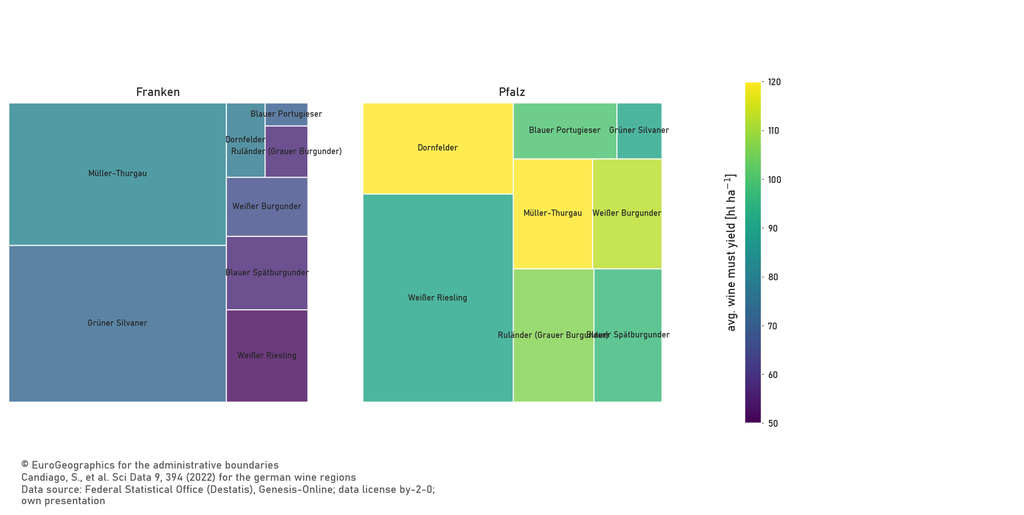

Figure 8: Visualization of the shares of different varieties of wine in the Franconia and Palatinate wine-growing regions and their respective yields. Franconia (or *Franken*) is clearly dominated by white grapes making up for more than 72% of the area under vines. In the Palatinate (or *Pfalz*) wine-growing region, ‘Weißer Riesling’ dominates in terms of area, but Dornfelder grapes produce the highest yields.

## Footnotes

[^1]: 103,391 hectares as of 2022. Quelle: Statistisches Bundesamt Genesis-Online 41252-0005
[^2]: Candiago, S., Tscholl, S., Bassani, L. *et al.* A geospatial inventory of regulatory information for wine protected designations of origin in Europe. *Sci Data* **9**, 394 (2022). https://doi.org/10.1038/s41597-022-01513-0
[^3]: Candiago, S., Tscholl, S., Bassani, L. *et al.* A geospatial inventory of regulatory information for wine protected designations of origin in Europe. *Sci Data* **9**, 394 (2022). https://doi.org/10.1038/s41597-022-01513-0